# Are manual or automatic cars more fuel efficient?

Sam Baker

2019-09-07

## Introduction

Car owners are becoming increasingly conscious of the impact their vehicles have on the environment. This coupled with the financial cost of filling a car with petrol has made miles per gallon (mpg) a key metric in car performance. Thus understanding the factors which may affect miles per gallon is a worthy area of investigation.

## Aims and data

This analysis will focus on how the transmission of a car affects its miles per gallon. In particular, it will aim to do the following:

1. Answer whether an automatic or manual transmission is better for miles per gallon
2. Quantify the miles per gallon difference between automatic and manual transmissions

The data comes from the Motor Trend Car Road Tests (mtcars) dataset in R. “The data was extracted from the 1974 Motor Trend US magazine, and comprises fuel consumption and 10 aspects of automobile design and performance for 32 automobiles.

## Data Wrangling

We begin by loading some packages that we will use for data manipulation and visualisation.

```r
# Load packages
require(ggplot2)
require(tidyr)
require(purrr)
require(MASS)
require(lmtest)
```

Next we load the mtcars dataset and perform some initial data manipulation. In particular we convert the engine shape (vs) and transmission type (am) to factors.

```r
data(mtcars)
mtcars$vs <- factor(mtcars$vs)
levels(mtcars$vs) = c("V", "S")
mtcars$am <- factor(mtcars$am)
levels(mtcars$am) = c("A", "M")
```

## Exploratory Analysis

Let’s take an initial look at the contents of our dataset.

```r
str(mtcars)
```

```
## 'data.frame':    32 obs. of  11 variables:
##  $ mpg : num  21 21 22.8 21.4 18.7 18.1 14.3 24.4 22.8 19.2 ...
##  $ cyl : num  6 6 4 6 8 6 8 4 4 6 ...
##  $ disp: num  160 160 108 258 360 ...
##  $ hp  : num  110 110 93 110 175 105 245 62 95 123 ...
##  $ drat: num  3.9 3.9 3.85 3.08 3.15 2.76 3.21 3.69 3.92 3.92 ...
##  $ wt  : num  2.62 2.88 2.32 3.21 3.44 ...
##  $ qsec: num  16.5 17 18.6 19.4 17 ...
##  $ vs  : Factor w/ 2 levels "V","S": 1 1 2 2 1 2 1 2 2 2 ...
##  $ am  : Factor w/ 2 levels "A","M": 2 2 2 1 1 1 1 1 1 1 ...
##  $ gear: num  4 4 4 3 3 3 3 4 4 4 ...
##  $ carb: num  4 4 1 1 2 1 4 2 2 4 ...
```

The dataset contains the following variables  
1. mpg: Miles/(US) gallon  
2. cyl: Number of cylinders  
3. disp: Displacement (cu.in.)  
4. hp: Gross horsepower  
5. drat: Rear axle ratio  
6. wt: Weight (1000 lbs)  
7. qsec: 1/4 mile time  
8. vs: Engine shape (V = V-shaped or S = straight)  
9. am: Transmission (A = automatic, M = manual)  
10. gear: Number of forward gears  
11. carb: Number of carburetors

A plot of mpg by transmission type reveals that mpg is (on average) higher for manual cars.

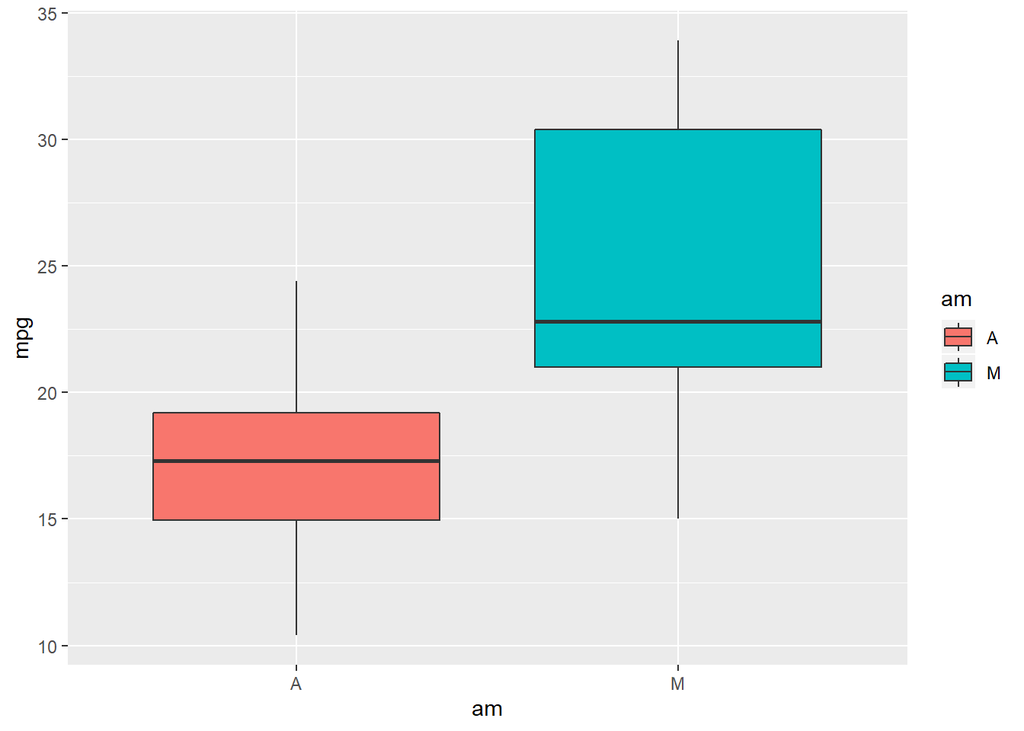

A t-test is performed to assess whether this difference is statistically significant.

```r
t.test(mtcars$mpg[mtcars$am == "A"], mtcars$mpg[mtcars$am == "M"], alternative = c("less"))
```

```
##
##  Welch Two Sample t-test
##
## data:  mtcars$mpg[mtcars$am == "A"] and mtcars$mpg[mtcars$am == "M"]
## t = -3.7671, df = 18.332, p-value = 0.0006868
## alternative hypothesis: true difference in means is less than 0
## 95 percent confidence interval:
##       -Inf -3.913256
## sample estimates:
## mean of x mean of y
##  17.14737  24.39231
```

With a p-value of 0.0006868, we can reject the null hypothesis (at the 1% significance level) that the mean mpg across the two transmission types is the same.

Whilst we have seen that the mpg for manual cars is higher, we need to investigate whether this is due to other confounding factors. We make some further exploratory plots.

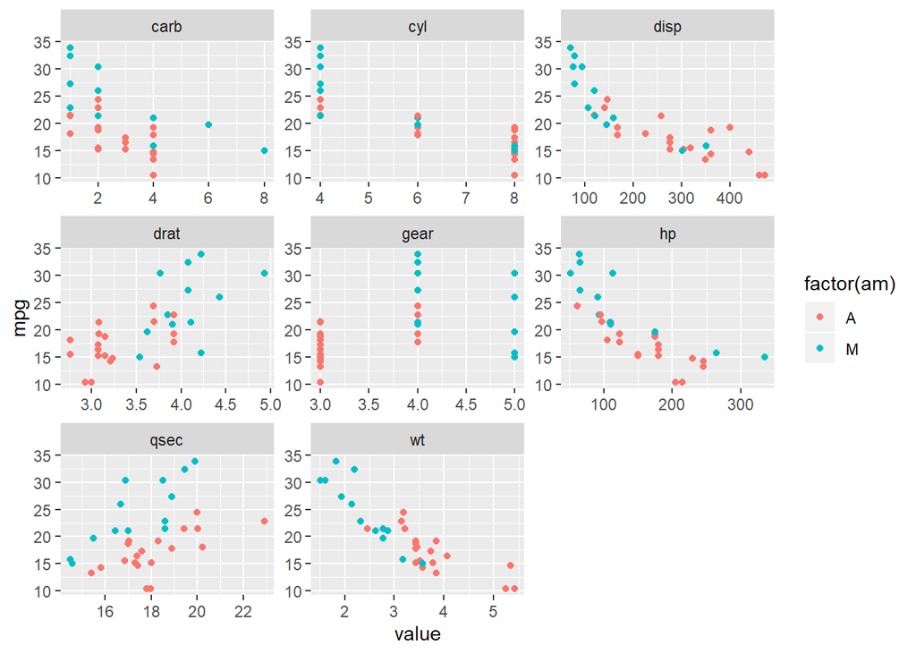

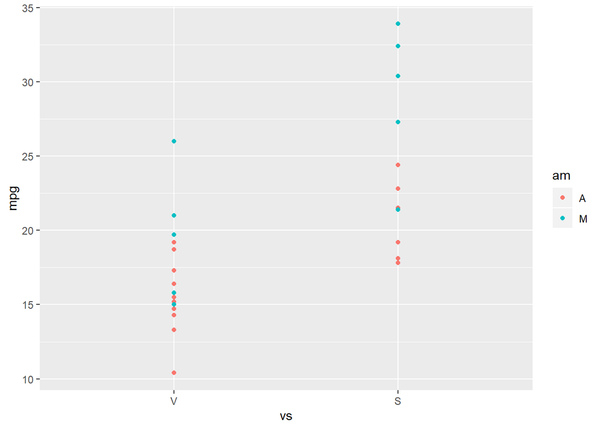

From these exploratory graphs, the following initial observations are made:  
* Weight and horsepower have a strong negative trend with mpg. Also automatic cars tend to be heavier and more powerful.  
* Quarter mile time (qsec) and mpg have a positive trend. There is no association between qsec and transmission, perhaps because whilst automatic cars tend to be heavier, they are also more powerful, both of which will affect their quarter mile time.  
* Rear axel ratio has a positive trend with mpg. Also automatic cars tend to have a lower ratio.  
* There is a strong negative trend between displacement and mpg. Automatic cars tend to have higher displacement.  
* Displacement is a measure of the volume of the cylinders within an engine, hence unsurprisingly the result with displacement is mirrored with cylinders. That is more cylinders (hence higher displacement) corresponds to fewer mpg.  
* V-shaped engines tend to have lower mpg than straight engines. There does not seem to be an association between transmission and engine shape.  
* Automatic cars tend to have fewer gears. There is some evidence that having four gear gives the best mpg and three gears gives the worst mpg.  
* There is a negative trend between number of carburetors and mpg. There is a some evidence that automatic cars have fewer carburetors.

Following this initial exploratory analysis we expect that horsepower, weight, and displacement may be relevant as they exhibited strong trend with mpg and strong association with transmission type.